# Reglas de Asociación - Implicaciones

Proyecto III

Jakub Maciążek  
- Faculty of Information and Communication Technology, Wrocław University of Science and Technology

# 1 Project description

**Social Network Analysis**

For this project we will use the data obtained from Twitter used for a research article that we published in the Knowledge-Based Systems Journal on the topic of social network analysis using FCA. The objective was to identify leaders of the social network.

- download dataset
- dataset stores topics (rows) treated by means of communication (columns)
- process in what you consider (reduce, discretize, group, etc.) - justify if you do it due to excessive computing time, etc.

**Basic analysis**

- Extract patterns or association rules using arules
- Extract knowledge using fcaR

It’s not about copy-paste commands. Data analysis involves extracting useful knowledge, drawing conclusions. Extract patterns, visualize, show hidden knowledge with any technique from the themes of implications and association rules.

Explain the steps you are taking.

**Going deeper**

- Open section for you to think of something interesting that you are able to extract from the dataset analysis using rules or FCA.
- Identify media that really act as leaders? either
- What are the most important topics? either
- Is there interesting knowledge in the lattice? On the left side of the implications? attributes that are repeated a lot in association rules?, …

# 2 Basic analysis

## 2.1 Initial data analysis

We will begin with data import.

```r
sn <- read.csv("S:/0_Universidad_de_Malaga/MI_Ingenieria_y_ciencia_de_datos/Estatistica_avanzada_para_ciencia_de_datos/Reglas_de_asociacion/proyecto_tercera_parte/5000 de 26 medios completo-1.csv",  sep=";", row.names = 1, colClasses=c("character", rep("numeric",26)))
head(sn)
```

```
##              Al.Jazeera.English BBC.News..World. Bloomberg.Business
## #gaza1yearon                  1                0                  0
## #gazalife                     1                0                  0
## #1mdb                         0                1                  0
## #acdc                         0                1                  0
## #bbccycling                   0                1                  0
## #bbcgofigure                  0                1                  0
##              Breaking.News Champions.League CNN.International Eurosport
## #gaza1yearon             0                0                 0         0
## #gazalife                0                0                 0         0
## #1mdb                    0                0                 0         0
## #acdc                    0                0                 0         0
## #bbccycling              0                0                 0         0
## #bbcgofigure             0                0                 0         0
##              Financial.Times Forbes Formula.1 Huffington.Post Le.Tour.de.France
## #gaza1yearon               0      0         0               0                 0
## #gazalife                  0      0         0               0                 0
## #1mdb                      0      0         0               0                 0
## #acdc                      0      0         0               0                 0
## #bbccycling                0      0         0               0                 0
## #bbcgofigure               0      0         0               0                 0
##              MotoGPŞ National.Geographic Premier.League Reuters.Top.News
## #gaza1yearon       0                   0              0                0
## #gazalife          0                   0              0                0
## #1mdb              0                   0              0                0
## #acdc              0                   0              0                0
## #bbccycling        0                   0              0                0
## #bbcgofigure       0                   0              0                0
##              Sky.Sports Sports.Illustrated The.Associated.Press The.Economist
## #gaza1yearon          0                  0                    0             0
## #gazalife             0                  0                    0             0
## #1mdb                 0                  0                    0             0
## #acdc                 0                  0                    0             0
## #bbccycling           0                  0                    0             0
## #bbcgofigure          0                  0                    0             0
##              The.Guardian The.New.York.Times TIME.com UEFA.com
## #gaza1yearon            0                  0        0        0
## #gazalife               0                  0        0        0
## #1mdb                   0                  0        0        0
## #acdc                   0                  0        0        0
## #bbccycling             0                  0        0        0
## #bbcgofigure            0                  0        0        0
##              Wall.Street.Journal Washington.Post
## #gaza1yearon                   0               0
## #gazalife                      0               0
## #1mdb                          0               0
## #acdc                          0               0
## #bbccycling                    0               0
## #bbcgofigure                   0               0
```

```r
sapply(sn, class)
```

```
##   Al.Jazeera.English     BBC.News..World.   Bloomberg.Business
##            "numeric"            "numeric"            "numeric"
##        Breaking.News     Champions.League    CNN.International
##            "numeric"            "numeric"            "numeric"
##            Eurosport      Financial.Times               Forbes
##            "numeric"            "numeric"            "numeric"
##            Formula.1      Huffington.Post    Le.Tour.de.France
##            "numeric"            "numeric"            "numeric"
##              MotoGPŞ  National.Geographic       Premier.League
##            "numeric"            "numeric"            "numeric"
##     Reuters.Top.News           Sky.Sports   Sports.Illustrated
##            "numeric"            "numeric"            "numeric"
## The.Associated.Press        The.Economist         The.Guardian
##            "numeric"            "numeric"            "numeric"
##   The.New.York.Times             TIME.com             UEFA.com
##            "numeric"            "numeric"            "numeric"
##  Wall.Street.Journal      Washington.Post
##            "numeric"            "numeric"
```

## 2.2 Arules analysis

Removal of columns where all values are 0 (Media didn’t occure in any topic).

```r
sn_processed <- sn
sn_processed <- subset(sn, select = -c(Breaking.News, Financial.Times))
```

As single value data were removed, associations can be generated.

Despite different attempts, data suitable for correct arules analysis was not achieved.

## 2.3 Formal Concept Analysis

FCA is able to work with binary data, therefore no transformation is needed.

We will begin with creating formal context, with which we can see the dimensions of dataset: 233 hashtags and 26 medias.

```r
fc_sn <- FormalContext$new(sn)
fc_sn$print()
## FormalContext with 233 objects and 26 attributes.
##                      Al.Jazeera.English  BBC.News..World.  Bloomberg.Business
##         #gaza1yearon          X
##            #gazalife          X
##                #1mdb                             X
##                #acdc                             X
##          #bbccycling                             X
##         #bbcgofigure                             X
##        #dailycommute                             X
##  #dontjudgechallange                             X
##               #ebola                             X
##            #flooding                             X
## Other attributes are: Breaking.News, Champions.League, CNN.International,
## Eurosport, Financial.Times, Forbes, ...
```

Those media companies are:

```r
fc_sn$attributes
```

```
##  [1] "Al.Jazeera.English"   "BBC.News..World."     "Bloomberg.Business"
##  [4] "Breaking.News"        "Champions.League"     "CNN.International"
##  [7] "Eurosport"            "Financial.Times"      "Forbes"
## [10] "Formula.1"            "Huffington.Post"      "Le.Tour.de.France"
## [13] "MotoGPŞ"              "National.Geographic"  "Premier.League"
## [16] "Reuters.Top.News"     "Sky.Sports"           "Sports.Illustrated"
## [19] "The.Associated.Press" "The.Economist"        "The.Guardian"
## [22] "The.New.York.Times"   "TIME.com"             "UEFA.com"
## [25] "Wall.Street.Journal"  "Washington.Post"
```

And hashtags include:

```r
sort(fc_sn$objects)
```

```
##   [1] "#1mdb"                      "#2degrees"
##   [3] "#65yearsoff1"               "#acdc"
##   [5] "#aftertheflag"              "#albertocontador"
##   [7] "#alcoa"                     "#allezalm"
##   [9] "#amiens"                    "#ap"
##  [11] "#ap10things"                "#aptopix"
##  [13] "#arras"                     "#arrastdf"
##  [15] "#arsenalsingapore"          "#ashes"
##  [17] "#ashes2015"                 "#ashesverdict"
##  [19] "#askbautista"               "#askbobgale"
##  [21] "#askbradl"                  "#askwenger"
##  [23] "#aussiecorner"              "#avfc"
##  [25] "#baba"                      "#backstage"
##  [27] "#bangkok"                   "#bat"
##  [29] "#bat2015"                   "#bbccycling"
```

[output cut: 102 more lines]

We can visualize relationship between them with:

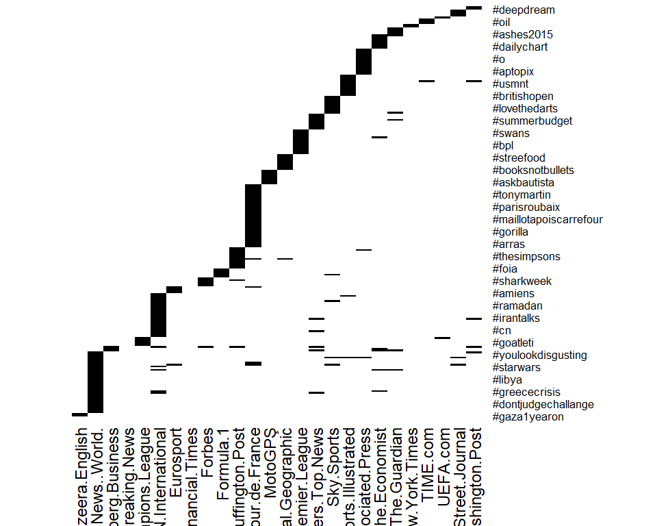

```r
fc_sn$plot()
```

From this plot we can also initialy say that:

- Most active companies are mainly: BBC.News..World., CNN.International and Le.Tour.de.France.
- Most popular hastags on the otherhand seem to be mainly: starwars, youlookdisgusting and goatleti.

### 2.3.1 Concept analysis

We can calculate concepts using Ganter and Wille’s NextClosure algorithm. Without any restrictions, 54 concepts can be found.

```r
#Find concepts
fc_sn$find_concepts()
#Number of found concepts
fc_sn$concepts$size()
```

```
## [1] 54
```

```r
#Some of the concepts
head(fc_sn$concepts)
## A set of 6 concepts:
## 1: ({#gaza1yearon, #gazalife, #1mdb, #acdc, #bbccycling, #bbcgofigure, #dailycommute, #dontjudgechallange, #ebola, #flooding, #gaza, #gazawarchildren, #gre, #greece, #greececrisis, #holocaust, #irantalksvienna, #israel, #japan, #kyivpolice, #lasvegas, #libya, #nangka, #newsfromelsewhere, #obama, #robowars, #sevenseven, #sousseattack, #starwars, #tdf2015, #tourdefrance, #typhoon, #vyapamscam, #wimbledon, #ww1, #youlookdisgusting, #É, #budget2015, #grexit, #nyse, #euro2016, #fenerbahce, #goatleti, #supportyourlocalchampions, #ucl, #2degrees, #askbobgale, #bangkok, #china}, {})
## 2: ({#flooding, #gre, #israel, #nyse, #china}, {Washington.Post})
## 3: ({#dailycommute, #ebola, #bangkok}, {Wall.Street.Journal})
## 4: ({#greececrisis, #askbobgale}, {UEFA.com})
## 5: ({#nyse, #2degrees}, {TIME.com})
## 6: ({#ucl}, {The.New.York.Times})
```

### 2.3.2 Closures

Using closures we can calculate extents and intents based on popular values viewed on the plot.

```r
# Define a set of objects
S <- Set$new(attributes = fc_sn$objects)
S$assign("#starwars" = 1, "#youlookdisgusting" = 1, "#goatleti"=1)
fc_sn$intent(S)
## {}

S <- Set$new(attributes = fc_sn$objects)
S$assign("#starwars" = 1)
fc_sn$intent(S)
## {BBC.News..World., CNN.International}

S <- Set$new(attributes = fc_sn$objects)
S$assign("#youlookdisgusting" = 1)
fc_sn$intent(S)
## {BBC.News..World.}

S <- Set$new(attributes = fc_sn$objects)
S$assign("#goatleti"=1)
fc_sn$intent(S)
## {Champions.League}
```

From the number of intents it can be seen that hose topics are not that popular, and visual analysis was unprecise.

### 2.3.3 Concepts quality analysis

As can be seen, no true concepts of support higher than 0.2 are observed.

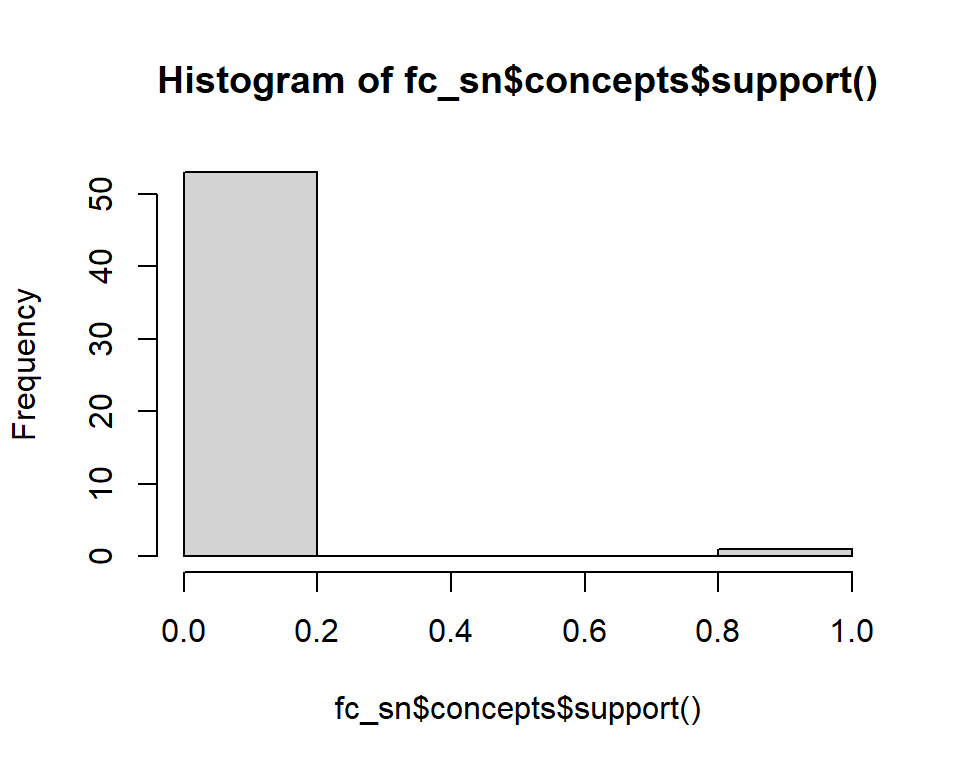

```r
hist(fc_sn$concepts$support())
```

```r
idx <- which(fc_sn$concepts$support() > 0.2)
sublattice <- fc_sn$concepts$sublattice(idx)
sublattice
## A set of 1 concepts:
## 1: ({#gaza1yearon, #gazalife, #1mdb, #acdc, #bbccycling, #bbcgofigure, #dailycommute, #dontjudgechallange, #ebola, #flooding, #gaza, #gazawarchildren, #gre, #greece, #greececrisis, #holocaust, #irantalksvienna, #israel, #japan, #kyivpolice, #lasvegas, #libya, #nangka, #newsfromelsewhere, #obama, #robowars, #sevenseven, #sousseattack, #starwars, #tdf2015, #tourdefrance, #typhoon, #vyapamscam, #wimbledon, #ww1, #youlookdisgusting, #É, #budget2015, #grexit, #nyse, #euro2016, #fenerbahce, #goatleti, #supportyourlocalchampions, #ucl, #2degrees, #askbobgale, #bangkok, #china}, {})
```

```r
idx <- which(fc_sn$concepts$support() > 0.1)
sublattice <- fc_sn$concepts$sublattice(idx)
sublattice
## A set of 7 concepts:
## 1: ({#gaza1yearon, #gazalife, #1mdb, #acdc, #bbccycling, #bbcgofigure, #dailycommute, #dontjudgechallange, #ebola, #flooding, #gaza, #gazawarchildren, #gre, #greece, #greececrisis, #holocaust, #irantalksvienna, #israel, #japan, #kyivpolice, #lasvegas, #libya, #nangka, #newsfromelsewhere, #obama, #robowars, #sevenseven, #sousseattack, #starwars, #tdf2015, #tourdefrance, #typhoon, #vyapamscam, #wimbledon, #ww1, #youlookdisgusting, #É, #budget2015, #grexit, #nyse, #euro2016, #fenerbahce, #goatleti, #supportyourlocalchampions, #ucl, #2degrees, #askbobgale, #bangkok, #china}, {})
## 2: ({#dailycommute, #dontjudgechallange, #libya, #sousseattack, #tdf2015}, {Le.Tour.de.France})
## 3: ({#1mdb, #acdc, #bbccycling, #bbcgofigure, #gre, #holocaust, #irantalksvienna, #israel, #japan, #kyivpolice}, {CNN.International})
## 4: ({#gazalife, #1mdb, #acdc, #bbccycling, #bbcgofigure, #dailycommute, #dontjudgechallange, #ebola, #flooding}, {BBC.News..World.})
## 5: ({#dailycommute, #dontjudgechallange}, {BBC.News..World., Le.Tour.de.France})
## 6: ({#1mdb, #acdc, #bbccycling, #bbcgofigure}, {BBC.News..World., CNN.International})
## 7: ({}, {Al.Jazeera.English, BBC.News..World., Bloomberg.Business, Breaking.News, Champions.League, CNN.International, Eurosport, Financial.Times, Forbes, Formula.1, Huffington.Post, Le.Tour.de.France, MotoGPŞ, National.Geographic, Premier.League, Reuters.Top.News, Sky.Sports, Sports.Illustrated, The.Associated.Press, The.Economist, The.Guardian, The.New.York.Times, TIME.com, UEFA.com, Wall.Street.Journal, Washington.Post})
sublattice$support()
```

```
## [1] 1.000000000 0.171673820 0.128755365 0.150214592 0.008583691 0.017167382
## [7] 0.000000000
```

```r
best_concepts <- sublattice[2:6]
best_concepts
## A set of 5 concepts:
## 1: ({#dailycommute, #dontjudgechallange, #libya, #sousseattack, #tdf2015}, {Le.Tour.de.France})
## 2: ({#1mdb, #acdc, #bbccycling, #bbcgofigure, #gre, #holocaust, #irantalksvienna, #israel, #japan, #kyivpolice}, {CNN.International})
## 3: ({#gazalife, #1mdb, #acdc, #bbccycling, #bbcgofigure, #dailycommute, #dontjudgechallange, #ebola, #flooding}, {BBC.News..World.})
## 4: ({#dailycommute, #dontjudgechallange}, {BBC.News..World., Le.Tour.de.France})
## 5: ({#1mdb, #acdc, #bbccycling, #bbcgofigure}, {BBC.News..World., CNN.International})
best_concepts$support()
```

```
## [1] 0.171673820 0.128755365 0.150214592 0.008583691 0.017167382
```

### 2.3.4 Implications

```r
fc_sn$find_implications()

fc_sn$implications$cardinality() #262
```

```
## [1] 262
```

```r
colSums(fc_sn$implications$size()) # Implication set with 262 implications.
```

```
##  LHS  RHS
##  524 5426
```

```r
fc_sn$implications$apply_rules(c("reduction",
                                      "composition",
                                      "generalization",
                                      "simplification",
                                      "rsimplification"))
## Processing batch
## --> Reduction: from 262 to 262.
## --> Composition: from 262 to 262.
## --> Generalization: from 262 to 262.
## --> Simplification: from 262 to 262.
## --> Right Simplification: from 262 to 262.
colSums(fc_sn$implications$size())
## LHS RHS
## 523 284
fc_sn$implications
## Implication set with 262 implications.
## Rule 1: {Wall.Street.Journal, Washington.Post} -> {Al.Jazeera.English,
##   Breaking.News, Champions.League, Financial.Times, Formula.1,
##   Le.Tour.de.France, MotoGPŞ, National.Geographic, Premier.League,
##   The.Associated.Press, The.Economist, The.Guardian, The.New.York.Times,
##   TIME.com, UEFA.com}
## Rule 2: {UEFA.com, Washington.Post} -> {Wall.Street.Journal}
## Rule 3: {UEFA.com, Wall.Street.Journal} -> {Washington.Post}
## Rule 4: {TIME.com, Washington.Post} -> {Sports.Illustrated}
## Rule 5: {TIME.com, Wall.Street.Journal} -> {Washington.Post}
## Rule 6: {TIME.com, UEFA.com} -> {Washington.Post}
## Rule 7: {The.New.York.Times, Washington.Post} -> {Wall.Street.Journal}
## Rule 8: {The.New.York.Times, Wall.Street.Journal} -> {Washington.Post}
## Rule 9: {The.New.York.Times, UEFA.com} -> {Washington.Post}
## Rule 10: {The.New.York.Times, TIME.com} -> {Washington.Post}
## Rule 11: {The.Guardian, Washington.Post} -> {Wall.Street.Journal}
## Rule 12: {The.Guardian, Wall.Street.Journal} -> {Washington.Post}
## Rule 13: {The.Guardian, UEFA.com} -> {Washington.Post}
## Rule 14: {The.Guardian, TIME.com} -> {Washington.Post}
## Rule 15: {The.Guardian, The.New.York.Times} -> {Washington.Post}
## Rule 16: {The.Economist, Washington.Post} -> {Wall.Street.Journal}
## Rule 17: {The.Economist, Wall.Street.Journal} -> {Washington.Post}
## Rule 18: {The.Economist, UEFA.com} -> {Washington.Post}
## Rule 19: {The.Economist, TIME.com} -> {Washington.Post}
## Rule 20: {The.Economist, The.New.York.Times} -> {Washington.Post}
## Rule 21: {The.Associated.Press, Washington.Post} -> {Wall.Street.Journal}
## Rule 22: {The.Associated.Press, Wall.Street.Journal} -> {Sky.Sports,
##   Sports.Illustrated}
## Rule 23: {The.Associated.Press, UEFA.com} -> {Washington.Post}
## Rule 24: {The.Associated.Press, TIME.com} -> {Washington.Post}
## Rule 25: {The.Associated.Press, The.New.York.Times} -> {Washington.Post}
## Rule 26: {The.Associated.Press, The.Guardian} -> {Washington.Post}
## Rule 27: {The.Associated.Press, The.Economist} -> {Washington.Post}
## Rule 28: {Sports.Illustrated, Washington.Post} -> {TIME.com}
## Rule 29: {Sports.Illustrated, Wall.Street.Journal} -> {The.Associated.Press}
## Rule 30: {Sports.Illustrated, UEFA.com} -> {Washington.Post}
## Rule 31: {Sports.Illustrated, TIME.com} -> {Washington.Post}
## Rule 32: {Sports.Illustrated, The.New.York.Times} -> {Washington.Post}
## Rule 33: {Sports.Illustrated, The.Guardian} -> {Washington.Post}
## Rule 34: {Sports.Illustrated, The.Economist} -> {Washington.Post}
## Rule 35: {Sports.Illustrated, The.Associated.Press} -> {Wall.Street.Journal}
## Rule 36: {Sky.Sports, Washington.Post} -> {Wall.Street.Journal}
## Rule 37: {Sky.Sports, Wall.Street.Journal} -> {BBC.News..World.}
## Rule 38: {Sky.Sports, UEFA.com} -> {Washington.Post}
## Rule 39: {Sky.Sports, TIME.com} -> {Washington.Post}
## Rule 40: {Sky.Sports, The.New.York.Times} -> {Washington.Post}
## Rule 41: {Sky.Sports, The.Economist} -> {Washington.Post}
## Rule 42: {Sky.Sports, The.Associated.Press} -> {Wall.Street.Journal}
## Rule 43: {Sky.Sports, Sports.Illustrated} -> {Wall.Street.Journal}
## Rule 44: {Reuters.Top.News, Washington.Post} -> {CNN.International}
## Rule 45: {Reuters.Top.News, Wall.Street.Journal} -> {Washington.Post}
## Rule 46: {Reuters.Top.News, UEFA.com} -> {Washington.Post}
## Rule 47: {Reuters.Top.News, TIME.com} -> {Wall.Street.Journal}
## Rule 48: {Reuters.Top.News, The.New.York.Times} -> {Washington.Post}
## Rule 49: {Reuters.Top.News, The.Economist} -> {Bloomberg.Business, The.Guardian}
## Rule 50: {Reuters.Top.News, The.Associated.Press} -> {Washington.Post}
## Rule 51: {Reuters.Top.News, Sports.Illustrated} -> {Wall.Street.Journal}
## Rule 52: {Reuters.Top.News, Sky.Sports} -> {Washington.Post}
## Rule 53: {Premier.League, Washington.Post} -> {Wall.Street.Journal}
## Rule 54: {Premier.League, Wall.Street.Journal} -> {Washington.Post}
## Rule 55: {Premier.League, UEFA.com} -> {Washington.Post}
## Rule 56: {Premier.League, TIME.com} -> {Washington.Post}
## Rule 57: {Premier.League, The.New.York.Times} -> {Washington.Post}
## Rule 58: {Premier.League, The.Guardian} -> {Washington.Post}
## Rule 59: {Premier.League, The.Associated.Press} -> {Washington.Post}
## Rule 60: {Premier.League, Sports.Illustrated} -> {Washington.Post}
## Rule 61: {Premier.League, Sky.Sports} -> {Washington.Post}
## Rule 62: {Premier.League, Reuters.Top.News} -> {Washington.Post}
## Rule 63: {National.Geographic, Washington.Post} -> {Wall.Street.Journal}
## Rule 64: {National.Geographic, Wall.Street.Journal} -> {Washington.Post}
## Rule 65: {National.Geographic, UEFA.com} -> {Washington.Post}
## Rule 66: {National.Geographic, TIME.com} -> {Washington.Post}
## Rule 67: {National.Geographic, The.New.York.Times} -> {Washington.Post}
## Rule 68: {National.Geographic, The.Guardian} -> {Washington.Post}
## Rule 69: {National.Geographic, The.Economist} -> {Washington.Post}
## Rule 70: {National.Geographic, The.Associated.Press} -> {Washington.Post}
## Rule 71: {National.Geographic, Sports.Illustrated} -> {Washington.Post}
## Rule 72: {National.Geographic, Sky.Sports} -> {Washington.Post}
## Rule 73: {National.Geographic, Reuters.Top.News} -> {Washington.Post}
## Rule 74: {National.Geographic, Premier.League} -> {Washington.Post}
## Rule 75: {MotoGPŞ, Washington.Post} -> {Wall.Street.Journal}
## Rule 76: {MotoGPŞ, Wall.Street.Journal} -> {Washington.Post}
## Rule 77: {MotoGPŞ, UEFA.com} -> {Washington.Post}
## Rule 78: {MotoGPŞ, TIME.com} -> {Washington.Post}
## Rule 79: {MotoGPŞ, The.New.York.Times} -> {Washington.Post}
## Rule 80: {MotoGPŞ, The.Guardian} -> {Washington.Post}
## Rule 81: {MotoGPŞ, The.Economist} -> {Washington.Post}
## Rule 82: {MotoGPŞ, The.Associated.Press} -> {Washington.Post}
## Rule 83: {MotoGPŞ, Sports.Illustrated} -> {Washington.Post}
## Rule 84: {MotoGPŞ, Sky.Sports} -> {Washington.Post}
## Rule 85: {MotoGPŞ, Reuters.Top.News} -> {Washington.Post}
## Rule 86: {MotoGPŞ, Premier.League} -> {Washington.Post}
## Rule 87: {MotoGPŞ, National.Geographic} -> {Washington.Post}
## Rule 88: {Le.Tour.de.France, Washington.Post} -> {Wall.Street.Journal}
## Rule 89: {Le.Tour.de.France, Wall.Street.Journal} -> {Eurosport, Sky.Sports}
## Rule 90: {Le.Tour.de.France, UEFA.com} -> {Washington.Post}
## Rule 91: {Le.Tour.de.France, TIME.com} -> {Washington.Post}
## Rule 92: {Le.Tour.de.France, The.New.York.Times} -> {Washington.Post}
## Rule 93: {Le.Tour.de.France, The.Guardian} -> {Washington.Post}
## Rule 94: {Le.Tour.de.France, The.Economist} -> {Washington.Post}
## Rule 95: {Le.Tour.de.France, The.Associated.Press} -> {Washington.Post}
## Rule 96: {Le.Tour.de.France, Sports.Illustrated} -> {Washington.Post}
## Rule 97: {Le.Tour.de.France, Sky.Sports} -> {Wall.Street.Journal}
## Rule 98: {Le.Tour.de.France, Reuters.Top.News} -> {Washington.Post}
## Rule 99: {Le.Tour.de.France, Premier.League} -> {Washington.Post}
## Rule 100: {Le.Tour.de.France, National.Geographic} -> {Huffington.Post}
## Rule 101: {Le.Tour.de.France, MotoGPŞ} -> {Washington.Post}
## Rule 102: {Huffington.Post, Washington.Post} -> {Bloomberg.Business, Forbes,
##   Reuters.Top.News}
## Rule 103: {Huffington.Post, Wall.Street.Journal} -> {Washington.Post}
## Rule 104: {Huffington.Post, UEFA.com} -> {Washington.Post}
## Rule 105: {Huffington.Post, TIME.com} -> {Wall.Street.Journal}
## Rule 106: {Huffington.Post, The.New.York.Times} -> {Washington.Post}
## Rule 107: {Huffington.Post, The.Guardian} -> {Washington.Post}
## Rule 108: {Huffington.Post, The.Economist} -> {Washington.Post}
## Rule 109: {Huffington.Post, Sports.Illustrated} -> {Wall.Street.Journal}
## Rule 110: {Huffington.Post, Sky.Sports} -> {Washington.Post}
## Rule 111: {Huffington.Post, Reuters.Top.News} -> {Washington.Post}
## Rule 112: {Huffington.Post, Premier.League} -> {Washington.Post}
## Rule 113: {Huffington.Post, National.Geographic} -> {Le.Tour.de.France}
## Rule 114: {Huffington.Post, MotoGPŞ} -> {Washington.Post}
## Rule 115: {Huffington.Post, Le.Tour.de.France} -> {National.Geographic}
## Rule 116: {Formula.1, Washington.Post} -> {Wall.Street.Journal}
## Rule 117: {Formula.1, Wall.Street.Journal} -> {Washington.Post}
## Rule 118: {Formula.1, UEFA.com} -> {Washington.Post}
## Rule 119: {Formula.1, TIME.com} -> {Washington.Post}
## Rule 120: {Formula.1, The.New.York.Times} -> {Washington.Post}
## Rule 121: {Formula.1, The.Guardian} -> {Washington.Post}
## Rule 122: {Formula.1, The.Economist} -> {Washington.Post}
## Rule 123: {Formula.1, The.Associated.Press} -> {Washington.Post}
## Rule 124: {Formula.1, Sports.Illustrated} -> {Washington.Post}
## Rule 125: {Formula.1, Reuters.Top.News} -> {Washington.Post}
## Rule 126: {Formula.1, Premier.League} -> {Washington.Post}
## Rule 127: {Formula.1, National.Geographic} -> {Washington.Post}
## Rule 128: {Formula.1, MotoGPŞ} -> {Washington.Post}
## Rule 129: {Formula.1, Le.Tour.de.France} -> {Washington.Post}
## Rule 130: {Formula.1, Huffington.Post} -> {Washington.Post}
## Rule 131: {Forbes, Washington.Post} -> {Huffington.Post}
## Rule 132: {Forbes, Wall.Street.Journal} -> {Washington.Post}
## Rule 133: {Forbes, UEFA.com} -> {Washington.Post}
## Rule 134: {Forbes, TIME.com} -> {Wall.Street.Journal}
## Rule 135: {Forbes, The.New.York.Times} -> {Washington.Post}
## Rule 136: {Forbes, The.Guardian} -> {Washington.Post}
## Rule 137: {Forbes, The.Economist} -> {Washington.Post}
## Rule 138: {Forbes, The.Associated.Press} -> {Washington.Post}
## Rule 139: {Forbes, Sports.Illustrated} -> {Wall.Street.Journal}
## Rule 140: {Forbes, Sky.Sports} -> {Washington.Post}
## Rule 141: {Forbes, Reuters.Top.News} -> {Washington.Post}
## Rule 142: {Forbes, Premier.League} -> {Washington.Post}
## Rule 143: {Forbes, National.Geographic} -> {Washington.Post}
## Rule 144: {Forbes, MotoGPŞ} -> {Washington.Post}
## Rule 145: {Forbes, Le.Tour.de.France} -> {Washington.Post}
## Rule 146: {Forbes, Formula.1} -> {Washington.Post}
## Rule 147: {Financial.Times} -> {Wall.Street.Journal, Washington.Post}
## Rule 148: {Eurosport, Washington.Post} -> {Wall.Street.Journal}
## Rule 149: {Eurosport, Wall.Street.Journal} -> {Le.Tour.de.France}
## Rule 150: {Eurosport, UEFA.com} -> {Washington.Post}
## Rule 151: {Eurosport, TIME.com} -> {Washington.Post}
## Rule 152: {Eurosport, The.New.York.Times} -> {Washington.Post}
## Rule 153: {Eurosport, The.Guardian} -> {Washington.Post}
## Rule 154: {Eurosport, The.Economist} -> {Washington.Post}
## Rule 155: {Eurosport, The.Associated.Press} -> {Washington.Post}
## Rule 156: {Eurosport, Sports.Illustrated} -> {Washington.Post}
## Rule 157: {Eurosport, Sky.Sports} -> {Wall.Street.Journal}
## Rule 158: {Eurosport, Reuters.Top.News} -> {Washington.Post}
## Rule 159: {Eurosport, Premier.League} -> {Washington.Post}
## Rule 160: {Eurosport, National.Geographic} -> {Washington.Post}
## Rule 161: {Eurosport, MotoGPŞ} -> {Washington.Post}
## Rule 162: {Eurosport, Huffington.Post} -> {Washington.Post}
## Rule 163: {Eurosport, Formula.1} -> {Washington.Post}
## Rule 164: {Eurosport, Forbes} -> {Washington.Post}
## Rule 165: {CNN.International, Washington.Post} -> {Reuters.Top.News}
## Rule 166: {CNN.International, Wall.Street.Journal} -> {Washington.Post}
## Rule 167: {CNN.International, UEFA.com} -> {Washington.Post}
## Rule 168: {CNN.International, TIME.com} -> {Wall.Street.Journal}
## Rule 169: {CNN.International, The.New.York.Times} -> {Washington.Post}
```

```r
## Rule 170: {CNN.International, The.Guardian} -> {The.Economist}
## Rule 171: {CNN.International, The.Economist} -> {BBC.News..World.}
## Rule 172: {CNN.International, The.Associated.Press} -> {Washington.Post}
## Rule 173: {CNN.International, Premier.League} -> {Washington.Post}
## Rule 174: {CNN.International, National.Geographic} -> {Washington.Post}
## Rule 175: {CNN.International, MotoGPŞ} -> {Washington.Post}
## Rule 176: {CNN.International, Le.Tour.de.France} -> {Washington.Post}
## Rule 177: {CNN.International, Huffington.Post} -> {Washington.Post}
## Rule 178: {CNN.International, Formula.1} -> {Washington.Post}
## Rule 179: {CNN.International, Forbes} -> {Washington.Post}
## Rule 180: {CNN.International, Eurosport} -> {Washington.Post}
## Rule 181: {Champions.League, Washington.Post} -> {Wall.Street.Journal}
## Rule 182: {Champions.League, Wall.Street.Journal} -> {Washington.Post}
## Rule 183: {Champions.League, TIME.com} -> {Washington.Post}
## Rule 184: {Champions.League, The.New.York.Times} -> {Washington.Post}
## Rule 185: {Champions.League, The.Guardian} -> {Washington.Post}
## Rule 186: {Champions.League, The.Economist} -> {Washington.Post}
## Rule 187: {Champions.League, The.Associated.Press} -> {Washington.Post}
## Rule 188: {Champions.League, Sports.Illustrated} -> {Washington.Post}
## Rule 189: {Champions.League, Sky.Sports} -> {Washington.Post}
## Rule 190: {Champions.League, Reuters.Top.News} -> {Washington.Post}
## Rule 191: {Champions.League, Premier.League} -> {Washington.Post}
## Rule 192: {Champions.League, National.Geographic} -> {Washington.Post}
## Rule 193: {Champions.League, MotoGPŞ} -> {Washington.Post}
## Rule 194: {Champions.League, Le.Tour.de.France} -> {Washington.Post}
## Rule 195: {Champions.League, Huffington.Post} -> {Washington.Post}
## Rule 196: {Champions.League, Formula.1} -> {Washington.Post}
## Rule 197: {Champions.League, Forbes} -> {Washington.Post}
## Rule 198: {Champions.League, Eurosport} -> {Washington.Post}
## Rule 199: {Champions.League, CNN.International} -> {Washington.Post}
## Rule 200: {Breaking.News} -> {Wall.Street.Journal, Washington.Post}
## Rule 201: {Bloomberg.Business, Washington.Post} -> {Huffington.Post}
## Rule 202: {Bloomberg.Business, Wall.Street.Journal} -> {Washington.Post}
## Rule 203: {Bloomberg.Business, UEFA.com} -> {Washington.Post}
## Rule 204: {Bloomberg.Business, TIME.com} -> {Wall.Street.Journal}
## Rule 205: {Bloomberg.Business, The.New.York.Times} -> {Washington.Post}
## Rule 206: {Bloomberg.Business, The.Guardian} -> {Reuters.Top.News,
##   The.Economist}
## Rule 207: {Bloomberg.Business, The.Associated.Press} -> {Washington.Post}
## Rule 208: {Bloomberg.Business, Sports.Illustrated} -> {Wall.Street.Journal}
## Rule 209: {Bloomberg.Business, Sky.Sports} -> {Washington.Post}
## Rule 210: {Bloomberg.Business, Premier.League} -> {Washington.Post}
## Rule 211: {Bloomberg.Business, National.Geographic} -> {Washington.Post}
## Rule 212: {Bloomberg.Business, MotoGPŞ} -> {Washington.Post}
## Rule 213: {Bloomberg.Business, Le.Tour.de.France} -> {Washington.Post}
## Rule 214: {Bloomberg.Business, Huffington.Post} -> {Washington.Post}
## Rule 215: {Bloomberg.Business, Formula.1} -> {Washington.Post}
## Rule 216: {Bloomberg.Business, Forbes} -> {Washington.Post}
## Rule 217: {Bloomberg.Business, Eurosport} -> {Washington.Post}
## Rule 218: {Bloomberg.Business, CNN.International} -> {Washington.Post}
## Rule 219: {Bloomberg.Business, Champions.League} -> {Washington.Post}
## Rule 220: {BBC.News..World., Wall.Street.Journal} -> {Sky.Sports}
## Rule 221: {BBC.News..World., UEFA.com} -> {Washington.Post}
## Rule 222: {BBC.News..World., TIME.com} -> {Wall.Street.Journal}
## Rule 223: {BBC.News..World., The.New.York.Times} -> {Washington.Post}
## Rule 224: {BBC.News..World., The.Guardian} -> {The.Economist}
## Rule 225: {BBC.News..World., The.Economist} -> {CNN.International}
## Rule 226: {BBC.News..World., The.Associated.Press} -> {Wall.Street.Journal}
## Rule 227: {BBC.News..World., Sports.Illustrated} -> {Wall.Street.Journal}
## Rule 228: {BBC.News..World., Sky.Sports} -> {Wall.Street.Journal}
## Rule 229: {BBC.News..World., Reuters.Top.News} -> {CNN.International}
## Rule 230: {BBC.News..World., Premier.League} -> {Washington.Post}
## Rule 231: {BBC.News..World., National.Geographic} -> {Washington.Post}
## Rule 232: {BBC.News..World., MotoGPŞ} -> {Washington.Post}
## Rule 233: {BBC.News..World., Huffington.Post} -> {Wall.Street.Journal}
## Rule 234: {BBC.News..World., Formula.1} -> {Washington.Post}
## Rule 235: {BBC.News..World., Forbes} -> {Wall.Street.Journal}
## Rule 236: {BBC.News..World., Eurosport} -> {Wall.Street.Journal}
## Rule 237: {BBC.News..World., Reuters.Top.News, Washington.Post} ->
##   {Wall.Street.Journal}
## Rule 238: {BBC.News..World., Champions.League} -> {Washington.Post}
## Rule 239: {BBC.News..World., Bloomberg.Business} -> {Wall.Street.Journal}
## Rule 240: {Al.Jazeera.English, Washington.Post} -> {Wall.Street.Journal}
## Rule 241: {Al.Jazeera.English, Wall.Street.Journal} -> {Washington.Post}
## Rule 242: {Al.Jazeera.English, UEFA.com} -> {Washington.Post}
## Rule 243: {Al.Jazeera.English, TIME.com} -> {Washington.Post}
## Rule 244: {Al.Jazeera.English, The.New.York.Times} -> {Washington.Post}
## Rule 245: {Al.Jazeera.English, The.Guardian} -> {Washington.Post}
## Rule 246: {Al.Jazeera.English, The.Economist} -> {Washington.Post}
## Rule 247: {Al.Jazeera.English, The.Associated.Press} -> {Washington.Post}
## Rule 248: {Al.Jazeera.English, Sports.Illustrated} -> {Washington.Post}
## Rule 249: {Al.Jazeera.English, Sky.Sports} -> {Washington.Post}
## Rule 250: {Al.Jazeera.English, Reuters.Top.News} -> {Washington.Post}
## Rule 251: {Al.Jazeera.English, Premier.League} -> {Washington.Post}
## Rule 252: {Al.Jazeera.English, National.Geographic} -> {Washington.Post}
## Rule 253: {Al.Jazeera.English, MotoGPŞ} -> {Washington.Post}
## Rule 254: {Al.Jazeera.English, Le.Tour.de.France} -> {Washington.Post}
## Rule 255: {Al.Jazeera.English, Huffington.Post} -> {Washington.Post}
## Rule 256: {Al.Jazeera.English, Formula.1} -> {Washington.Post}
## Rule 257: {Al.Jazeera.English, Forbes} -> {Washington.Post}
## Rule 258: {Al.Jazeera.English, Eurosport} -> {Washington.Post}
## Rule 259: {Al.Jazeera.English, CNN.International} -> {Washington.Post}
## Rule 260: {Al.Jazeera.English, Champions.League} -> {Washington.Post}
## Rule 261: {Al.Jazeera.English, Bloomberg.Business} -> {Washington.Post}
## Rule 262: {Al.Jazeera.English, BBC.News..World.} -> {Washington.Post}
```

# 3 Deeper analysis

As arules analysis failed, this part was not conducted.